# Lab 07 - Smokers in Whickham

Simpson’s paradox

Moriah Ruggerio

[figure not shown]

A study of conducted in Whickham, England recorded participants’ age, smoking status at baseline, and then 20 years later recorded their health outcome. In this lab we analyse the relationships between these variables, first two at a time, and then controlling for the third.

# Learning goals

- Visualising relationships between variables
- Discovering Simpson’s paradox via visualisations

# Getting started

Go to the course GitHub organization and locate your homework repo, clone it in RStudio and open the R Markdown document. Knit the document to make sure it compiles without errors.

## Warm up

Before we introduce the data, let’s warm up with some simple exercises. Update the YAML of your R Markdown file with your information, knit, commit, and push your changes. Make sure to commit with a meaningful commit message. Then, go to your repo on GitHub and confirm that your changes are visible in your Rmd **and** md files. If anything is missing, commit and push again.

## Packages

We’ll use the **tidyverse** package for much of the data wrangling and visualisation and the data lives in the **mosaicData** package. These packages are already installed for you. You can load them by running the following in your Console:

```r
library(tidyverse)
library(mosaicData)
```

## Data

The dataset we’ll use is called Whickham from the **mosaicData** package. You can find out more about the dataset by inspecting their documentation, which you can access by running `?Whickham` in the Console or using the Help menu in RStudio to search for `Whickham`.

# Exercises

1. What type of study do you think these data come from: observational or experiment? Why?

*This data was from an observational study as there were no assigned treatment groups for the people involved.*

2. How many observations are in this dataset? What does each observation represent?

*There are 1314 observations in the dataset. Each observation represents one women in the study.*

3. How many variables are in this dataset? What type of variable is each? Display each variable using an appropriate visualization.

*There are 3 variables in this dataset. `Outcome` and `smoker` are both character data with 2 level factors. `Age` is numerical data.*

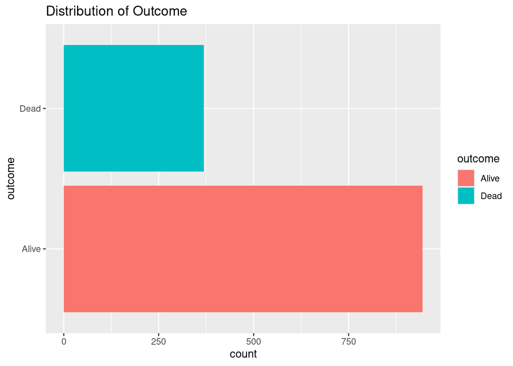

```r
ggplot(data = Whickham, aes(y = outcome, fill = outcome)) +
  geom_bar() +
  ggtitle("Distribution of Outcome")
```

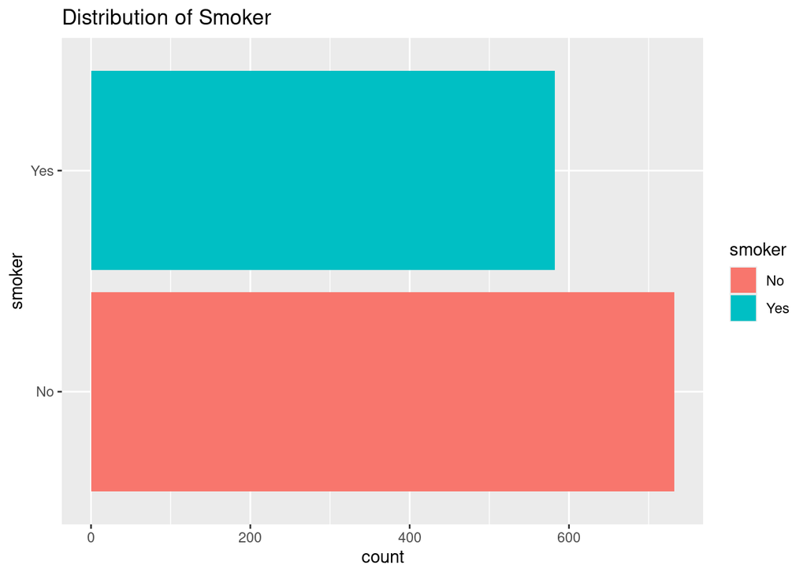

```r
ggplot(data = Whickham, aes(y = smoker, fill = smoker)) +
  geom_bar() +
  ggtitle("Distribution of Smoker")
```

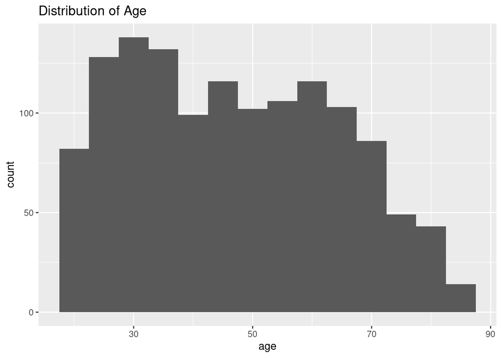

```r
ggplot(data = Whickham, aes(x = age)) +
  geom_histogram(binwidth = 5) +
  ggtitle("Distribution of Age")
```

4. What would you expect the relationship between smoking status and health outcome to be?

*I expect that smokers will have worse health outcomes (more likely to be dead) than non-smokers.*

🧶 ✅ ⬆️ Knit, *commit, and push your changes to GitHub with an appropriate commit message. Make sure to commit and push all changed files so that your Git pane is cleared up afterwards.*

5. Create a visualization depicting the relationship between smoking status and health outcome. Briefly describe the relationship, and evaluate whether this meets your expectations. Additionally, calculate the relevant conditional probabilities to help your narrative. Here is some code to get you started:

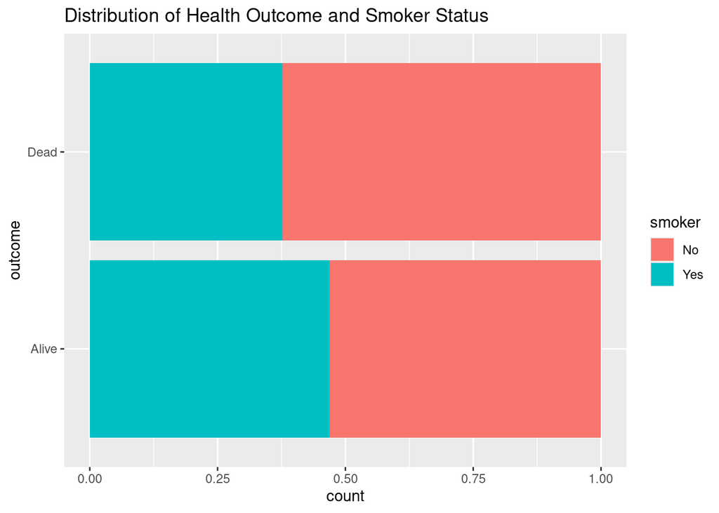

```r
ggplot(data = Whickham, aes(y = outcome, fill = smoker)) +
  geom_bar(position = "fill") +
  ggtitle("Distribution of Health Outcome and Smoker Status")
```

```r
Whickham %>%
  count(smoker, outcome) %>%
  group_by(smoker) %>%
  mutate(prop.dead = n/sum(n))
```

```
## # A tibble: 4 × 4
## # Groups:   smoker [2]
##   smoker outcome     n prop.dead
##   <fct>  <fct>   <int>     <dbl>
## 1 No     Alive     502     0.686
## 2 No     Dead      230     0.314
## 3 Yes    Alive     443     0.761
## 4 Yes    Dead      139     0.239
```

*The relationship does not appear to match what I expected to happen. It appears that those who smoked had a higher probability of being alive 20 years later.*

6. Create a new variable called `age_cat` using the following scheme:
- `age <= 44 ~ "18-44"`
- `age > 44 & age <= 64 ~ "45-64"`
- `age > 64 ~ "65+"`
7. Re-create the visualization depicting the relationship between smoking status and health outcome, faceted by `age_cat`. What changed? What might explain this change? Extend the contingency table from earlier by breaking it down by age category and use it to help your narrative.

```r
Whickham %>%
  count(smoker, age_cat, outcome)
```

[output not shown]

🧶 ✅ ⬆️ Knit, *commit, and push your changes to GitHub with an appropriate commit message. Make sure to commit and push all changed files so that your Git pane is cleared up afterwards and review the md document on GitHub to make sure you’re happy with the final state of your work.*